# 17_A_ESmoothing_Trended

# Libraries

```r
library(fpp3)
library(patchwork)
```

# References

1. Hyndman, R.J., & Athanasopoulos, G. (2021). *Forecasting: principles and practice* (3rd ed.). https://otexts.com/fpp3/
2. Fable package documentation. Retrieved from:
   - https://fable.tidyverts.org/index.html and
   - https://fable.tidyverts.org/articles/fable.html
3. Hyndman, R. J., Koehler, A. B., Ord, J. K., & Snyder, R. D. (2008). *Forecasting with exponential smoothing: The state space approach*. Springer-Verlag.

# Note

This notebook is not original material, but rather based on ref. 1 with notes expanding on some of the concepts contained in the book.

# Motivation

So far we have seen **simple exponential smoothing**, a forecasting method that sits between the mean and the naive methods:

- The **naive** method gives every future forecast the same value, the last observation: all the weight on the latest observation.
- The **mean** method gives every future forecast the same value, with equal weight on every observation, however old.
- **Simple exponential smoothing** also gives every future forecast the same value, but that value is a weighted average with the largest weights on the most recent observations. The further back an observation lies, the smaller its weight.

We now want to introduce trend and seasonality into exponential smoothing.

Let us first recall the component form of simple exponential smoothing:

$$\begin{align*}
\text{Forecast equation} && \hat{y}_{t+h|t} & = \ell_{t}\\
\text{Smoothing equation} && \ell_{t} & = \alpha y_{t} + (1 - \alpha)\ell_{t-1},
\end{align*}$$

- $l_t$ is the level (or the smoothed value) of the series at time $t$
- $h = 1$ gives the fitted values
- $t = T$ gives the true forecasts beyond the training data

**Forecast equation**

- The forecast at *t+1* is the *estimated level at time t*.

**Smoothing equation**

- The *smoothing equation* gives the *estimated level of the series at each period t*.

**Flat forecasts**

- SES has a flat forecast function: all forecasts take the same value, the last level.

$$\begin{align*}
\hat{y}_{T+h|T} = \hat{y}_{T+1|T}= l_T \qquad h=2,3,\dots.
\end{align*}$$

# Holt’s linear trend method

Holt extended simple exponential smoothing to forecast data with a trend.

## Component form of the equations

Unlike for simple exponential smoothing, we will not derive the equations. We take them as given and interpret them below. For a derivation, see reference 3.

**Differences from simple exponential smoothing:**

- A new component, the **trend** $b_t$ (analogous to the level $l_t$),
  - with its own **equation**,
  - and its own smoothing parameter $\beta^*$ (analogous to $\alpha$).

$$\begin{align*}
\text{Forecast equation}&& \hat{y}_{t+h|t} &= \ell_{t} + hb_{t} \\
\text{Level equation} && \ell_{t} &= \alpha y_{t} + (1 - \alpha)(\ell_{t-1} + b_{t-1})\\
\text{Trend equation} && b_{t} &= \beta^*(\ell_{t} - \ell_{t-1}) + (1 -\beta^*)b_{t-1}
\end{align*}$$

where:

- $l_t$ denotes an **estimate of the level of the series at time t.**
- $b_t$ denotes an **estimate of the trend (slope) of the series at time t.**
- $\alpha$ is the **smoothing parameter for the level.** $0 <= \alpha <= 1$
- $\beta^*$ is the **smoothing parameter for the trend**. $0 <= \beta^* <= 1$.
  - The star is there because the session on the ETS taxonomy (fpp3 8.5) rewrites the equations with a $\beta$ that is a different number; $\beta^*$ is the one in these equations.

## Equations for the fitted values

To see how these equations fit a series with a trend, set $h=1$ in the forecast equation (fitted values are one-step-ahead forecasts on the training data), then shift it from $t+1$ to $t$ so that it lines up with the level and trend equations:

$$\begin{align*}
\text{Forecast equation for h = 1} && \hat{y}_{t+1|t} &= \ell_{t} + 1 \cdot b_{t} \\
\text{Particularize for t instead t+1} && \hat{y}_{t|t-1} &= \ell_{t-1} + 1 \cdot b_{t-1} && \text{(fitted value at t)} \\
\end{align*}$$

Therefore, the **equations for the fitted values are:**

$$\begin{align*}
\text{Fitted value at t}&& \hat{y}_{t|t-1} &= \ell_{t-1} + b_{t-1} \\
\text{Level at t} && \ell_{t} &= \alpha y_{t} + (1 - \alpha)(\ell_{t-1} + b_{t-1})\\
\text{Trend at t} && b_{t} &= \beta^*(\ell_{t} - \ell_{t-1}) + (1 -\beta^*)b_{t-1}
\end{align*}$$

**These equations give the fitted values, given**:

1. The values of the smoothing parameters $\alpha$, $\beta^*$.
2. An initial value for the level $l_{0}$.
3. An initial value for the trend $b_{0}$.

**With these, the fitted values are computed as follows:**

- For $t = 1$:
  1. $\hat{y}_{1|0} = \ell_{0} + b_{0}$
  2. $l_{1} = \alpha y_{1} + (1 - \alpha)(l_{0} + b_{0})$
     - The value of $l_1$ will be used in the trend equation next.
  3. $b_{1} = \beta^*(l_{1} - l_{0}) + (1 -\beta^*)b_{0}$
- For $t = 2$: we proceed in the same manner after having computed $l_1$ and $b_1$
- For $t = 3$: we proceed in the same manner after having computed $l_2$ and $b_2$
- …

The figure below helps picture the process:

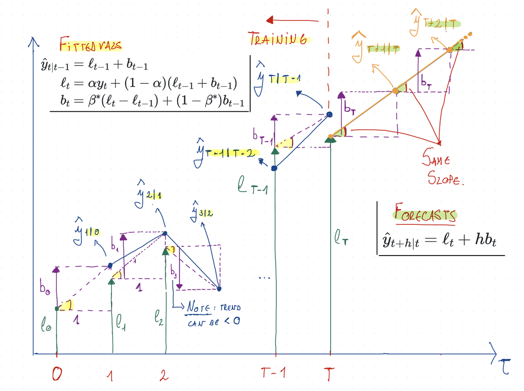

### Interpreting the equations

Now we can interpret the equations.

#### Level equation

The **level equation** says that $l_t$ **is a weighted average of the observation** $y_t$ and the **one-step-ahead forecast for time $t$**. The weights are set by $\alpha$, the smoothing parameter for the level.

$$\begin{align*}
\text{Level equation} && \ell_{t} &= \alpha \underbrace{y_{t}}_{\substack{\text{observation} \\ \text{at time } t}} + (1 - \alpha)\underbrace{(\ell_{t-1} + b_{t-1})}_{\substack{\text{one-step ahead} \\ \text{forecast at } t}}
\end{align*}$$

- **NOTE:** $\ell_{t-1} + b_{t-1}$ is the one-step-ahead forecast for time $t$: set $h = 1$ in the forecast equation and shift it back one step.

$$\begin{align*}
\text{Forecast equation for h = 1} && \hat{y}_{t+1|t} &= \ell_{t} + 1 \cdot b_{t} \\
\text{Particularize for t instead t+1} && \hat{y}_{t|t-1} &= \ell_{t-1} + 1 \cdot b_{t-1} \\
\end{align*}$$

- So $\ell_{t-1} + b_{t-1}$ is the one-step-ahead forecast for time $t$.

#### Trend equation

The **trend equation** says that $b_t$ is a weighted average of the trend estimated at time $t$ and the previous estimate of the trend. The weights are set by $\beta^*$.

$$\begin{align*}
\text{Trend equation} && b_{t} &= \beta^*\underbrace{(\ell_{t} - \ell_{t-1})}_{\substack{\text{estimated trend} \\ \text{at time } t}} + (1 -\beta^*)\underbrace{b_{t-1}}_{\substack{\text{previous} \\ \text{estimate} \\ \text{of the trend}}}
\end{align*}$$

- **NOTE:** $\ell_{t} - \ell_{t-1}$ is an **estimate of the trend at time $t$**, using only information up to $t$.
  - If the level $l_t$ estimates the value of the series, the difference between consecutive levels, divided by the one step between them, estimates the slope at time $t$. The figure below shows this:

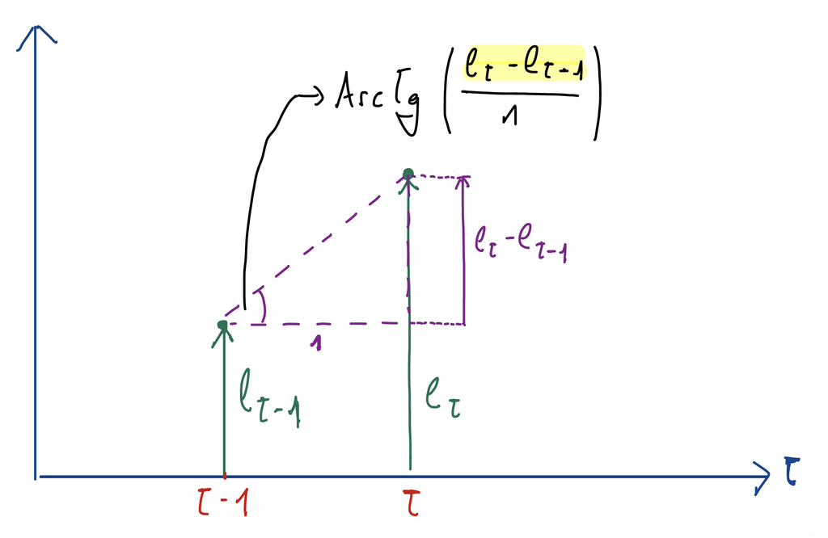

#### Equation for the fitted values

The fitted value at time $t$ is the previous level plus the previous slope: start at $l_{t-1}$ and climb one step along the slope $b_{t-1}$.

$$\begin{align*}
\text{Fitted value at t}&& \hat{y}_{t|t-1} &= \ell_{t-1} + 1 \cdot b_{t-1} \\
\end{align*}$$

## Equation for the forecasts

Once the fitted values, the levels $l_t$ and the slopes $b_t$ have been computed for every $t$ in the training data (from $t=1$ to $t=T$), the forecasts are:

$$\begin{align*}
\text{Forecast equation}&& \hat{y}_{T+h|T} &= \ell_{T} + hb_{T}
\end{align*}$$

By design, the **forecast function** is no longer flat but trending, with a constant slope $b_T$ (the last estimate of the trend).

- The **h-step-ahead forecast** is the **last level $l_T$** plus **h times the last slope $b_T$**: a straight line in $h$.

## Effect of the value of $\beta^*$

A $\beta^*$ that is too high makes the trend too responsive, so the fitted values chase every small fluctuation in the data. That is overfitting.

The graph below shows a series (in red) and its fitted values for $\alpha=0.4$ and $\beta^*$ from 0 to 1. Move the slider.

[interactive chart not shown]

## Fitting process

Fitting Holt’s method follows the same process as SES: minimize the sum of squared residuals (SSE), now over four values. We do not implement it from scratch this time; understanding the process is enough.

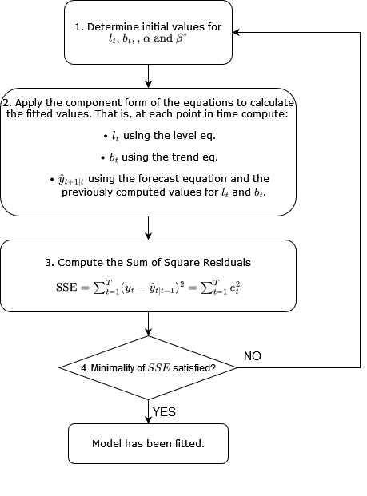

As an example, the table below shows steps 1 and 2 with $\hat{\alpha} = 0.9999$, $\hat{\beta}^* = 0.3267$, $l_0 = 10.05$ and $b_0 = 0.22$. It also extends ten steps beyond the training data, with the forecasts from the last level and slope:

| Year | Time | Observation | Level | Slope | Forecast |
| --- | --- | --- | --- | --- | --- |
|  | $t$ | $y_t$ | $l_t$ | $b_t$ | $\hat{y}_{t\|t-1}$ |
| 1959 | 0 |  | 10.05 | 0.22 |  |
| 1960 | 1 | 10.28 | 10.28 | 0.22 | 10.28 |
| 1961 | 2 | 10.48 | 10.48 | 0.22 | 10.50 |
| 1962 | 3 | 10.74 | 10.74 | 0.23 | 10.70 |
| 1963 | 4 | 10.95 | 10.95 | 0.22 | 10.97 |
| 1964 | 5 | 11.17 | 11.17 | 0.22 | 11.17 |
| 1965 | 6 | 11.39 | 11.39 | 0.22 | 11.39 |
| 1966 | 7 | 11.65 | 11.65 | 0.23 | 11.61 |
|  | $\vdots$ | $\vdots$ | $\vdots$ | $\vdots$ | $\vdots$ |
| 2014 | 55 | 23.50 | 23.50 | 0.37 | 23.52 |
| 2015 | 56 | 23.85 | 23.85 | 0.36 | 23.87 |
| 2016 | 57 | 24.21 | 24.21 | 0.36 | 24.21 |
| 2017 | 58 | 24.60 | 24.60 | 0.37 | 24.57 |
|  | $h$ |  |  |  | $\hat{y}_{T+h\|T}$ |
| 2018 | 1 |  |  |  | 24.97 |
| 2019 | 2 |  |  |  | 25.34 |
| 2020 | 3 |  |  |  | 25.71 |
| 2021 | 4 |  |  |  | 26.07 |
| 2022 | 5 |  |  |  | 26.44 |
| 2023 | 6 |  |  |  | 26.81 |
| 2024 | 7 |  |  |  | 27.18 |
| 2025 | 8 |  |  |  | 27.55 |
| 2026 | 9 |  |  |  | 27.92 |
| 2027 | 10 |  |  |  | 28.29 |

### Exercise: reproduce this table in Excel

The workbook `17_B` in this session’s folder has the template. Filling it in is part of the homework.

## R example: Australian population

Australia’s population from 1960 to 2017.

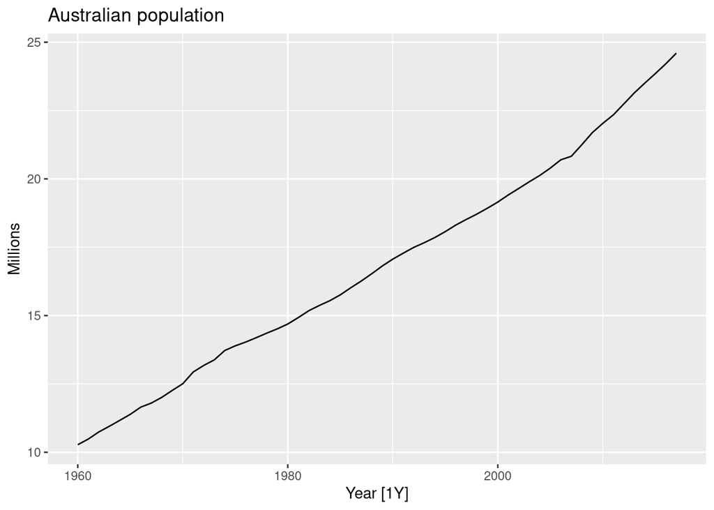

```r
aus_economy <- global_economy |>
  filter(Code == "AUS") |>
  mutate(Pop = Population / 1e6)
autoplot(aus_economy, Pop) +
  labs(y = "Millions", title = "Australian population")
```

This series clearly has a trend, so trended exponential smoothing is sensible.

`fable` does all the fitting with the following commands:

```r
fit <- aus_economy |>
  model(
    AAN = ETS(Pop ~ error("A") + trend("A") + season("N"))
  )
```

Remember the output is a `mable`, or model table. In other words, a table object containing the model objects we fitted (in this case only one model).

```r
fit
```

```
# A mable: 1 x 2
# Key:     Country [1]
  Country            AAN
  <fct>          <model>
1 Australia <ETS(A,A,N)>
```

As always, `tidy()` returns the parameters:

```r
tidy(fit)
```

```
# A tibble: 4 × 4
  Country   .model term  estimate
  <fct>     <chr>  <chr>    <dbl>
1 Australia AAN    alpha    1.000
2 Australia AAN    beta     0.327
3 Australia AAN    l[0]    10.1
4 Australia AAN    b[0]     0.222
```

`augment()` returns the fitted values and residuals; below it also gives the sum of squared residuals.

```r
fitted_vals <-
  fit |>
  augment()

resid <-  fitted_vals$.innov

# Sum of squared residuals
SSE <- sum(resid^2)
SSE
```

```
[1] 0.2231852
```

Forecasts come from `forecast()`, as usual:

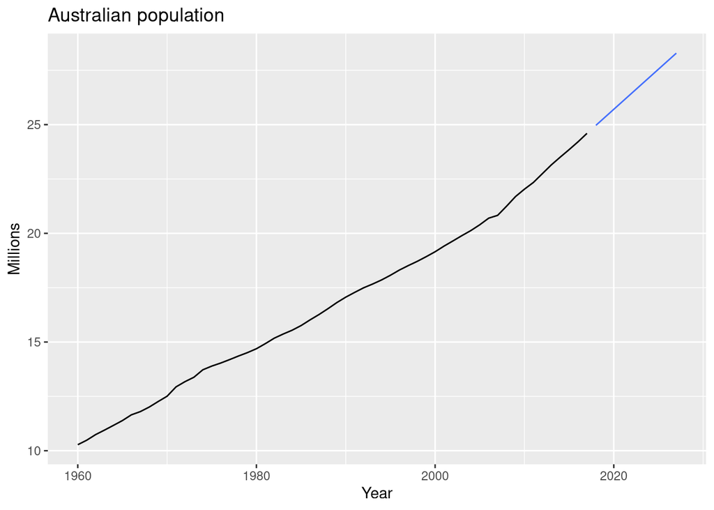

```r
fc <-
  fit |>
  forecast(h = 10)

fc |> autoplot(aus_economy, level = NULL) +
  labs(title = "Australian population",
       y = "Millions") +
  guides(colour = guide_legend(title = "Forecast"))
```

As expected, the h-step forecast is the last level plus h times the last slope: a straight line.

### Components of the model

Exponential smoothing can be read as a decomposition of the series into components. In the trended case they are the **level** $l_t$ and the **slope** $b_t$.

`components()` on an ETS model returns these components over the training data. Note the extra year, 1959, for $t=0$, which holds $l_0$ and $b_0$.

```r
holts_components <-
  fit |>
    components()

holts_components
```

```
# A dable: 59 x 7 [1Y]
# Key:     Country, .model [1]
# :        Pop = lag(level, 1) + lag(slope, 1) + remainder
   Country   .model  Year   Pop level slope remainder
   <fct>     <chr>  <dbl> <dbl> <dbl> <dbl>     <dbl>
 1 Australia AAN     1959  NA    10.1 0.222 NA
 2 Australia AAN     1960  10.3  10.3 0.222 -0.000145
 3 Australia AAN     1961  10.5  10.5 0.217 -0.0159
 4 Australia AAN     1962  10.7  10.7 0.231  0.0418
 5 Australia AAN     1963  11.0  11.0 0.223 -0.0229
 6 Australia AAN     1964  11.2  11.2 0.221 -0.00641
 7 Australia AAN     1965  11.4  11.4 0.221 -0.000314
 8 Australia AAN     1966  11.7  11.7 0.235  0.0418
 9 Australia AAN     1967  11.8  11.8 0.206 -0.0869
10 Australia AAN     1968  12.0  12.0 0.208  0.00350
# ℹ 49 more rows
```

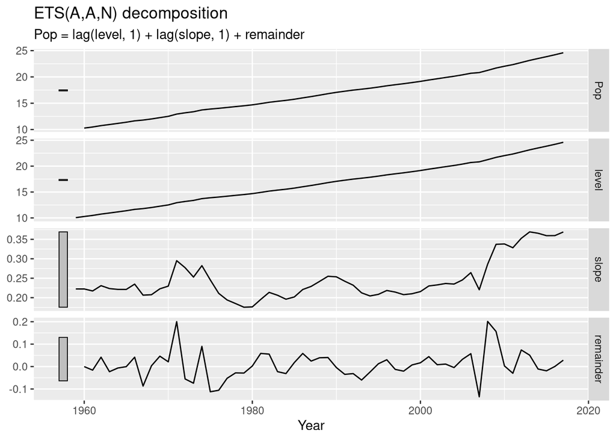

```r
# Depict the components
holts_components |> autoplot()
```

Just as in the Excel workbook, the fitted values can be computed from the level and the slope that `components()` returns, with the equation for the fitted values derived above:

$$\begin{align*}
\text{Fitted value at t}&& \hat{y}_{t|t-1} &= \ell_{t-1} + b_{t-1}
\end{align*}$$

```r
# Use the equation for the fitted values
holts_components <-
  holts_components |>
  mutate(
    .fitted = lag(level) + lag(slope) # Equation for the fitted vals
  )
```

They are the same fitted values that `augment()` returns:

```r
# Vector of fitted values computed using augment
fitted_augment <-
  fit |>
    augment() |>
    pull(.fitted)

# Vector of fitted values computed using the components() and the equation
fitted_components <-
  holts_components |>
  pull(.fitted)

# Remove NAs
fitted_components <-  fitted_components[!is.na(fitted_components)]

all.equal(fitted_augment, fitted_components)
```

```
[1] TRUE
```

# Damped trend methods

- **Holt’s linear method** has a constant trend, forever.
  - That is a problem for long forecast horizons: the forecasts tend to overshoot.
- **The damping parameter** $\phi$ bends the trend line toward a flat line some time into the future.
  - A very popular method, and a very successful one in forecasting competitions.
  - **One more parameter** on top of Holt’s, with $0<\phi<1$.
  - With $\phi = 1$ the method is Holt’s method.
  - With $0 < \phi < 1$ the trend is damped and the forecasts approach a constant:
    - $\ell_T+\phi b_T/(1-\phi)$ as $h \rightarrow \infty$.

The full component form, from fpp3 8.2:

$$\begin{align*}
\text{Forecast equation}&& \hat{y}_{t+h|t} &= \ell_{t} + (\phi+\phi^2 + \dots + \phi^{h})b_{t} \\
\text{Level equation} && \ell_{t} &= \alpha y_{t} + (1 - \alpha)(\ell_{t-1} + \phi b_{t-1})\\
\text{Trend equation} && b_{t} &= \beta^*(\ell_{t} - \ell_{t-1}) + (1 -\beta^*)\phi b_{t-1}
\end{align*}$$

The limit comes from the damping factors, which form a geometric sequence with ratio $\phi$:

$$\begin{align*}
\text{Forecast equation dampened method} && \hat{y}_{t+h|t} &= \ell_{t} + (\phi+\phi^2 + \dots + \phi^{h})b_{t} \\
\text{Forecast equation Holt's method} && \hat{y}_{t+h|t} &= \ell_{t} + hb_{t} \\
\end{align*}$$

The factor $h$ of Holt’s method has been replaced by the sum of a geometric sequence:

$$\begin{align*}
(\phi+\phi^2 + \dots + \phi^{h})
\end{align*}$$

Since the ratio $\phi$ is smaller than 1, the sum converges to $\phi/(1-\phi)$ as $h \rightarrow \infty$, so the forecast converges to $\ell_T+\phi b_T/(1-\phi)$.

Usual values for $\phi$:

- Rarely below 0.8: the damping is very strong for smaller values.
- Rarely above 0.98: otherwise the method is almost the same as the undamped one.

## Damped example 1: a fixed value for $\phi$

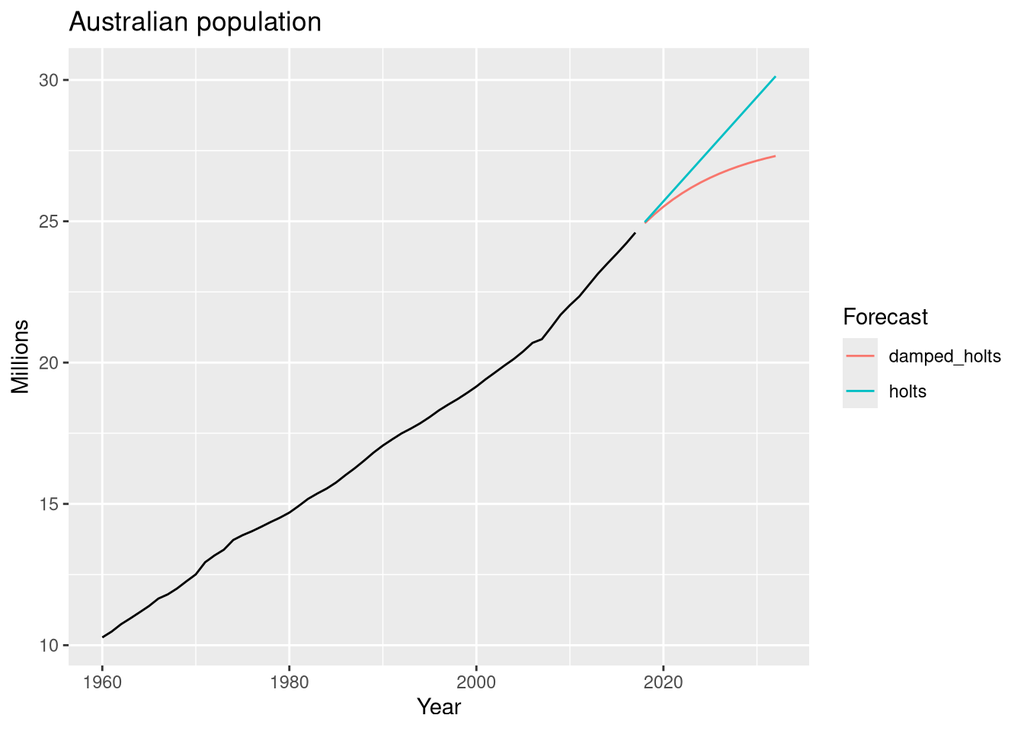

```r
fit_damped_1 <-
  aus_economy |>
    model(
      holts = ETS(Pop ~ error("A") + trend("A") + season("N")),

    # Damping parameter explicitly set to 0.9
     damped_holts = ETS(Pop ~ error("A") + trend("Ad", phi = 0.9) + season("N"))
  )

fc_damped_1 <-
  fit_damped_1 |>
  forecast(h = 15)

fc_damped_1 |>
  autoplot(aus_economy, level = NULL) +
  labs(title = "Australian population",
       y = "Millions") +
  guides(colour = guide_legend(title = "Forecast"))
```

A table comparing the forecasts of both models:

```r
fc_damped_1 |>
  as_tibble() |>
  select(Year, .model, .mean) |>
  pivot_wider(values_from = c(`.mean`), names_from = c(`.model`))
```

```
# A tibble: 15 × 3
    Year holts damped_holts
   <dbl> <dbl>        <dbl>
 1  2018  25.0         24.9
 2  2019  25.3         25.2
 3  2020  25.7         25.5
 4  2021  26.1         25.8
 5  2022  26.4         26.0
 6  2023  26.8         26.2
 7  2024  27.2         26.4
 8  2025  27.6         26.5
 9  2026  27.9         26.7
10  2027  28.3         26.8
11  2028  28.7         26.9
12  2029  29.0         27.0
13  2030  29.4         27.1
14  2031  29.8         27.2
15  2032  30.1         27.3
```

The damped method gives a lower forecast at every horizon, as expected.

## Damped example 2: a range for $\phi$, and `ETS()` picks within it

**Bounding phi**: `phi_range` gives a lower and an upper bound, and `ETS()` estimates $\phi$ within them:

```r
fit_damped_2 <-
  aus_economy |>
      model(
        holts = ETS(Pop ~ error("A") + trend("A") + season("N")),

        # Estimate phi between 0.8 and 0.95
        damped_holts = ETS(Pop ~ error("A") +
                                 trend("Ad", phi = NULL, phi_range=c(0.8, 0.95)) +
                                 season("N")
                      )
    )
```

```r
tidy(fit_damped_2)
```

```
# A tibble: 9 × 4
  Country   .model       term  estimate
  <fct>     <chr>        <chr>    <dbl>
1 Australia holts        alpha    1.000
2 Australia holts        beta     0.327
3 Australia holts        l[0]    10.1
4 Australia holts        b[0]     0.222
5 Australia damped_holts alpha    0.533
6 Australia damped_holts beta     0.533
7 Australia damped_holts phi      0.950
8 Australia damped_holts l[0]     9.96
9 Australia damped_holts b[0]     0.207
```

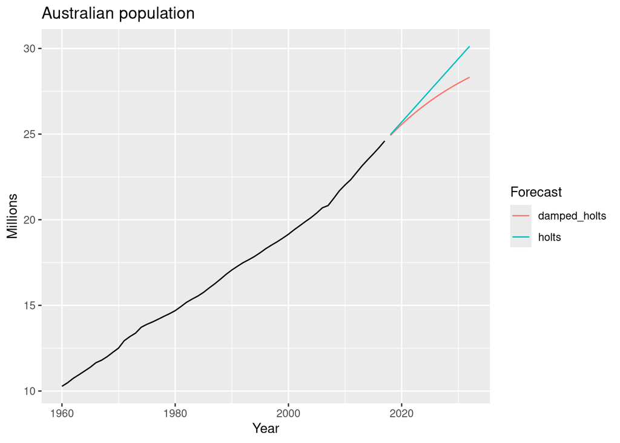

```r
fc_damped_2 <-
  fit_damped_2 |>
  forecast(h = 15)

fc_damped_2 |>
  autoplot(aus_economy, level = NULL) +
  labs(title = "Australian population",
       y = "Millions") +
  guides(colour = guide_legend(title = "Forecast"))
```

## Damped example 3: no value for $\phi$, and `ETS()` estimates it

`ETS()` estimates $\phi$ with the other parameters. For additive errors that is the same as minimizing the SSE; the session on the ETS taxonomy explains why.

```r
fit_damped_3 <-
  aus_economy |>
      model(
        holts = ETS(Pop ~ error("A") + trend("A") + season("N")),
        damped_holts = ETS(Pop ~ error("A") + trend("Ad") + season("N"))
      )
```

```r
tidy(fit_damped_3)
```

```
# A tibble: 9 × 4
  Country   .model       term  estimate
  <fct>     <chr>        <chr>    <dbl>
1 Australia holts        alpha    1.000
2 Australia holts        beta     0.327
3 Australia holts        l[0]    10.1
4 Australia holts        b[0]     0.222
5 Australia damped_holts alpha    0.999
6 Australia damped_holts beta     0.427
7 Australia damped_holts phi      0.980
8 Australia damped_holts l[0]    10.0
9 Australia damped_holts b[0]     0.248
```

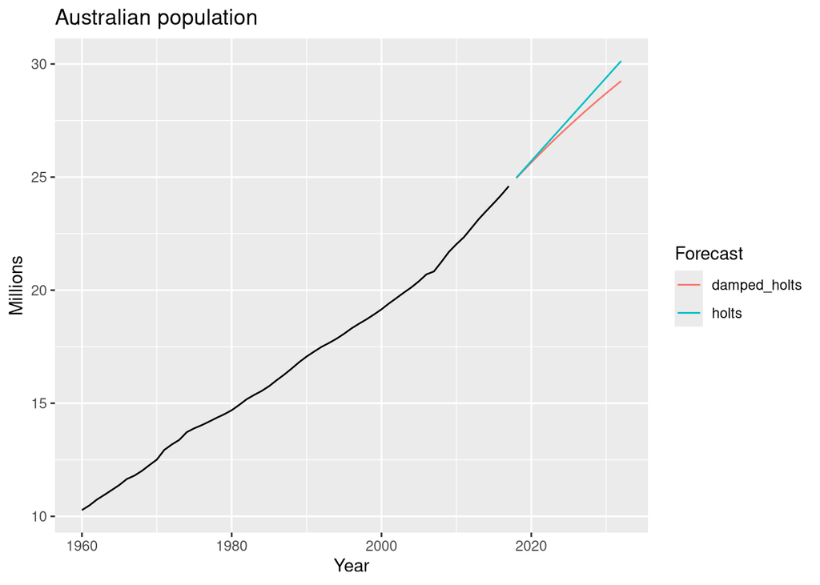

```r
fc_damped_3 <-
  fit_damped_3 |>
  forecast(h = 15)

fc_damped_3 |>
  autoplot(aus_economy, level = NULL) +
  labs(title = "Australian population",
       y = "Millions") +
  guides(colour = guide_legend(title = "Forecast"))
```

# Exercise 1: internet usage

The number of users connected to the internet through a server, observed over 100 minutes. Type `?WWWusage` for details (the dataset ships with base R).

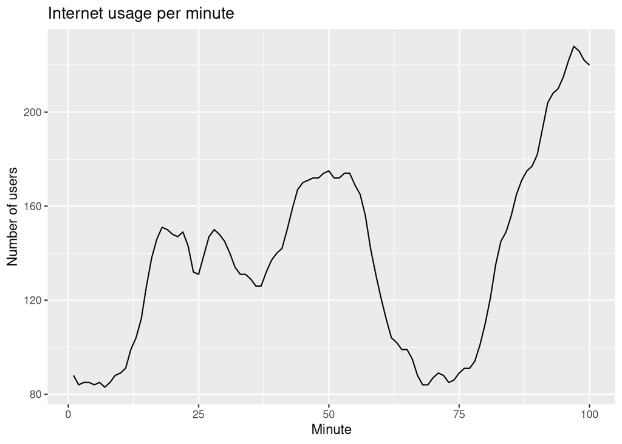

```r
# Convert time series object to tsibble object for compatibility with fable methods and tools
www_usage <- as_tsibble(WWWusage)

# Plot the data
www_usage |>
  autoplot(value) +
  labs(x="Minute", y="Number of users",
       title = "Internet usage per minute")
```

## 1. Fit models

Fit the following models:

1. A simple exponential smoothing model.
2. Holt’s linear trend model (additive trend).
3. A damped Holt model (additive damped trend).

## 2. Residual comparison

Briefly compare the residuals of Holt’s model and the damped Holt model, with the four properties from residual diagnostics (Session 9) and a Ljung-Box test at `lag = 10`: the data is not seasonal.

## 3. Perform forecasts

Use the three models and depict the forecasts. Create two separate graphs:

- **Graph 1:** the forecasts of all models with the historical data, without prediction intervals.
- **Graph 2:** the forecasts of the damped model with its prediction intervals.

# Exercise 2: internet usage, cross-validated

The same comparison as Exercise 1, this time with cross-validation.

Fit the following models:

1. A simple exponential smoothing model.
2. Holt’s linear trend model.
3. A damped Holt model.

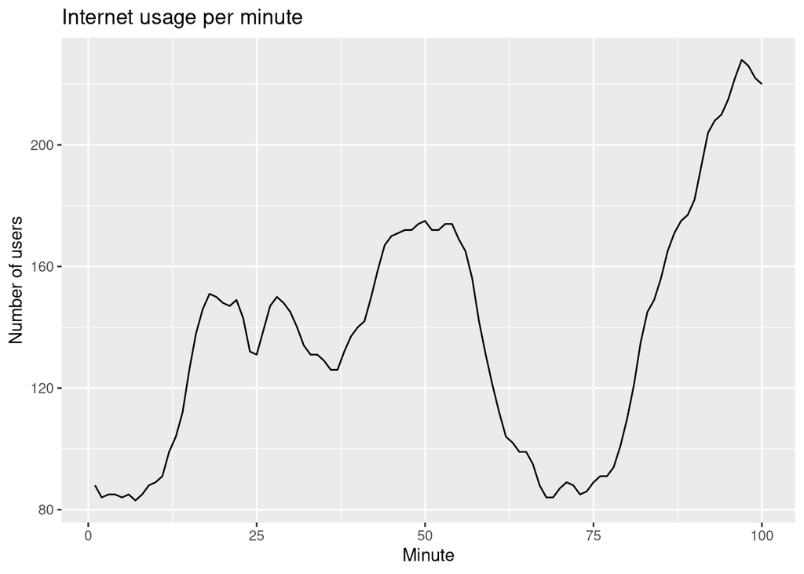

```r
# Convert time series object to tsibble object for compatibility with fable methods and tools
www_usage <- as_tsibble(WWWusage)

# Plot the data
www_usage |>
  autoplot(value) +
  labs(x="Minute", y="Number of users",
       title = "Internet usage per minute")
```

Use cross-validation to assess which method works best for this data.

- Forecast up to a horizon of 10.
- The smallest training set has 10 observations: at least as long as the horizon.
- Compute the accuracy metrics for each model and horizon, and for each model averaged over all horizons.

When you are done, take the best model on average over all horizons and:

- assess its residuals;
- forecast 10 steps ahead and plot the forecasts with their prediction intervals and the historical data.

### Step 1: create training datasets

Create the training sets with `stretch_tsibble()`, the smallest with 10 observations.

### Step 2: fit models to training datasets

Fit the models to every training set:

### Step 3: Perform forecasts and compute accuracy metrics